# Turtle_games

### Assignment Activity 1.ipynb

## *last modified: 2025-10-03 05:08:03*

```python
import statsmodels.api as sm
from sklearn import datasets
import numpy as np
from sklearn import linear_model
import pandas as pd
from statsmodels.stats.outliers_influence import variance_inflation_factor
import statsmodels.formula.api as smf
import sklearn
from sklearn.model_selection import train_test_split
from sklearn import metrics
from sklearn.linear_model import LinearRegression
import matplotlib.pyplot as plt
```

```python
reviews = pd.read_csv('turtle_reviews.csv')

reviews.columns = (reviews.columns.str.strip().str.lower().str.replace(r'\s+','_', regex=True))

print(reviews.shape)
reviews.head()
```

```
(2000, 11)
```

|  | gender | age | remuneration_(k£) | spending_score_(1-100) | loyalty_points | education | language | platform | product | review | summary |
| --- | --- | --- | --- | --- | --- | --- | --- | --- | --- | --- | --- |
| 0 | Male | 18 | 12.30 | 39 | 210 | graduate | EN | Web | 453 | When it comes to a DM's screen, the space on t... | The fact that 50% of this space is wasted on a... |
| 1 | Male | 23 | 12.30 | 81 | 524 | graduate | EN | Web | 466 | An Open Letter to GaleForce9*:\n\nYour unpaint... | Another worthless Dungeon Master's screen from... |
| 2 | Female | 22 | 13.12 | 6 | 40 | graduate | EN | Web | 254 | Nice art, nice printing. Why two panels are f... | pretty, but also pretty useless |
| 3 | Female | 25 | 13.12 | 77 | 562 | graduate | EN | Web | 263 | Amazing buy! Bought it as a gift for our new d... | Five Stars |
| 4 | Female | 33 | 13.94 | 40 | 366 | graduate | EN | Web | 291 | As my review of GF9's previous screens these w... | Money trap |

```python
reviews.dtypes, reviews.isna().sum()
```

```
(gender                     object
 age                         int64
 remuneration_(k£)         float64
 spending_score_(1-100)      int64
 loyalty_points              int64
 education                  object
 language                   object
 platform                   object
 product                     int64
 review                     object
 summary                    object
 dtype: object,
 gender                    0
 age                       0
 remuneration_(k£)         0
 spending_score_(1-100)    0
 loyalty_points            0
 education                 0
 language                  0
 platform                  0
 product                   0
 review                    0
 summary                   0
 dtype: int64)
```

```python
reviews = reviews.drop(columns=['language', 'platform'])

reviews
```

|  | gender | age | remuneration_(k£) | spending_score_(1-100) | loyalty_points | education | product | review | summary |
| --- | --- | --- | --- | --- | --- | --- | --- | --- | --- |
| 0 | Male | 18 | 12.30 | 39 | 210 | graduate | 453 | When it comes to a DM's screen, the space on t... | The fact that 50% of this space is wasted on a... |
| 1 | Male | 23 | 12.30 | 81 | 524 | graduate | 466 | An Open Letter to GaleForce9*:\n\nYour unpaint... | Another worthless Dungeon Master's screen from... |
| 2 | Female | 22 | 13.12 | 6 | 40 | graduate | 254 | Nice art, nice printing. Why two panels are f... | pretty, but also pretty useless |
| 3 | Female | 25 | 13.12 | 77 | 562 | graduate | 263 | Amazing buy! Bought it as a gift for our new d... | Five Stars |
| 4 | Female | 33 | 13.94 | 40 | 366 | graduate | 291 | As my review of GF9's previous screens these w... | Money trap |
| ... | ... | ... | ... | ... | ... | ... | ... | ... | ... |
| 1995 | Female | 37 | 84.46 | 69 | 4031 | PhD | 977 | The perfect word game for mixed ages (with Mom... | The perfect word game for mixed ages (with Mom |
| 1996 | Female | 43 | 92.66 | 8 | 539 | PhD | 979 | Great game. Did not think I would like it whe... | Super fun |
| 1997 | Male | 34 | 92.66 | 91 | 5614 | graduate | 1012 | Great game for all.........\nKeeps the mind ni... | Great Game |
| 1998 | Male | 34 | 98.40 | 16 | 1048 | PhD | 1031 | fun game! | Four Stars |
| 1999 | Male | 32 | 92.66 | 8 | 479 | PhD | 453 | This game is fun. A lot like scrabble without ... | Love this game |

2000 rows × 9 columns

```python
reviews = reviews.rename(columns={
    'remuneration_(k£)': 'remuneration',
    'spending_score_(1-100)': 'spending_score'
})

reviews
```

|  | gender | age | remuneration | spending_score | loyalty_points | education | product | review | summary |
| --- | --- | --- | --- | --- | --- | --- | --- | --- | --- |
| 0 | Male | 18 | 12.30 | 39 | 210 | graduate | 453 | When it comes to a DM's screen, the space on t... | The fact that 50% of this space is wasted on a... |
| 1 | Male | 23 | 12.30 | 81 | 524 | graduate | 466 | An Open Letter to GaleForce9*:\n\nYour unpaint... | Another worthless Dungeon Master's screen from... |
| 2 | Female | 22 | 13.12 | 6 | 40 | graduate | 254 | Nice art, nice printing. Why two panels are f... | pretty, but also pretty useless |
| 3 | Female | 25 | 13.12 | 77 | 562 | graduate | 263 | Amazing buy! Bought it as a gift for our new d... | Five Stars |
| 4 | Female | 33 | 13.94 | 40 | 366 | graduate | 291 | As my review of GF9's previous screens these w... | Money trap |
| ... | ... | ... | ... | ... | ... | ... | ... | ... | ... |
| 1995 | Female | 37 | 84.46 | 69 | 4031 | PhD | 977 | The perfect word game for mixed ages (with Mom... | The perfect word game for mixed ages (with Mom |
| 1996 | Female | 43 | 92.66 | 8 | 539 | PhD | 979 | Great game. Did not think I would like it whe... | Super fun |
| 1997 | Male | 34 | 92.66 | 91 | 5614 | graduate | 1012 | Great game for all.........\nKeeps the mind ni... | Great Game |
| 1998 | Male | 34 | 98.40 | 16 | 1048 | PhD | 1031 | fun game! | Four Stars |
| 1999 | Male | 32 | 92.66 | 8 | 479 | PhD | 453 | This game is fun. A lot like scrabble without ... | Love this game |

2000 rows × 9 columns

```python
reviews.to_csv('reviews.csv', index=False)
```

```python
reviews_clean = pd.read_csv('reviews.csv')

reviews_clean
```

|  | gender | age | remuneration | spending_score | loyalty_points | education | product | review | summary |
| --- | --- | --- | --- | --- | --- | --- | --- | --- | --- |
| 0 | Male | 18 | 12.30 | 39 | 210 | graduate | 453 | When it comes to a DM's screen, the space on t... | The fact that 50% of this space is wasted on a... |
| 1 | Male | 23 | 12.30 | 81 | 524 | graduate | 466 | An Open Letter to GaleForce9*:\n\nYour unpaint... | Another worthless Dungeon Master's screen from... |
| 2 | Female | 22 | 13.12 | 6 | 40 | graduate | 254 | Nice art, nice printing. Why two panels are f... | pretty, but also pretty useless |
| 3 | Female | 25 | 13.12 | 77 | 562 | graduate | 263 | Amazing buy! Bought it as a gift for our new d... | Five Stars |
| 4 | Female | 33 | 13.94 | 40 | 366 | graduate | 291 | As my review of GF9's previous screens these w... | Money trap |
| ... | ... | ... | ... | ... | ... | ... | ... | ... | ... |
| 1995 | Female | 37 | 84.46 | 69 | 4031 | PhD | 977 | The perfect word game for mixed ages (with Mom... | The perfect word game for mixed ages (with Mom |
| 1996 | Female | 43 | 92.66 | 8 | 539 | PhD | 979 | Great game. Did not think I would like it whe... | Super fun |
| 1997 | Male | 34 | 92.66 | 91 | 5614 | graduate | 1012 | Great game for all.........\nKeeps the mind ni... | Great Game |
| 1998 | Male | 34 | 98.40 | 16 | 1048 | PhD | 1031 | fun game! | Four Stars |
| 1999 | Male | 32 | 92.66 | 8 | 479 | PhD | 453 | This game is fun. A lot like scrabble without ... | Love this game |

2000 rows × 9 columns

```python
print(reviews.shape)
reviews.dtypes
```

```
(2000, 9)
```

```
gender             object
age                 int64
remuneration      float64
spending_score      int64
loyalty_points      int64
education          object
product             int64
review             object
summary            object
dtype: object
```

```python
reviews.head()
```

|  | gender | age | remuneration | spending_score | loyalty_points | education | product | review | summary |
| --- | --- | --- | --- | --- | --- | --- | --- | --- | --- |
| 0 | Male | 18 | 12.30 | 39 | 210 | graduate | 453 | When it comes to a DM's screen, the space on t... | The fact that 50% of this space is wasted on a... |
| 1 | Male | 23 | 12.30 | 81 | 524 | graduate | 466 | An Open Letter to GaleForce9*:\n\nYour unpaint... | Another worthless Dungeon Master's screen from... |
| 2 | Female | 22 | 13.12 | 6 | 40 | graduate | 254 | Nice art, nice printing. Why two panels are f... | pretty, but also pretty useless |
| 3 | Female | 25 | 13.12 | 77 | 562 | graduate | 263 | Amazing buy! Bought it as a gift for our new d... | Five Stars |
| 4 | Female | 33 | 13.94 | 40 | 366 | graduate | 291 | As my review of GF9's previous screens these w... | Money trap |

```python
# Define independent variable.
X_col = 'spending_score'

# Define dependent variable.
y_col = 'loyalty_points'
```

```python
# Create model and print summary of metrics.
model_spend = smf.ols(f'{y_col} ~ {X_col}', data=reviews).fit()
print("R-squared:", round(model_spend.rsquared, 4))
print("Adj. R-squared:", round(model_spend.rsquared_adj, 4))
```

```
R-squared: 0.452
Adj. R-squared: 0.4517
```

```python
# Extract the estimated parameters.
intercept = model_spend.params['Intercept']
beta_spend = model_spend.params[X_col]

# Extract the standard errors.
se_intercept = model_spend.bse['Intercept']
se_spend     = model_spend.bse[X_col]

# Extract the predicted values.
y_hat_spend = model_spend.predict(reviews)
```

```python
# Set the X coefficient and the constant to generate the regression table.
import pandas as pd
reg_table = pd.DataFrame({
    'term': ['Intercept', 'Spending score'],
    'coefficient': [intercept, beta_spend],
    'std_error': [se_intercept, se_spend],
    'p_value': [model_spend.pvalues['Intercept'], model_spend.pvalues[X_col]]
}).round(5)
```

```python
# View the output.
reg_table
```

|  | term | coefficient | std_error | p_value |
| --- | --- | --- | --- | --- |
| 0 | Intercept | -75.05266 | 45.93055 | 0.10241 |
| 1 | Spending score | 33.06169 | 0.81442 | 0.00000 |

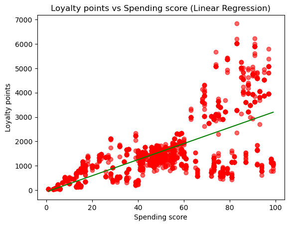

```python
# Plot the graph with a regression line.
import numpy as np
import matplotlib.pyplot as plt

plt.figure()
plt.scatter(reviews[X_col], reviews[y_col], alpha=0.6, color = 'red')

x_line = np.linspace(reviews[X_col].min(), reviews[X_col].max(), 200)
y_line = intercept + beta_spend * x_line
plt.plot(x_line, y_line, color = 'green')

plt.xlabel('Spending score')
plt.ylabel('Loyalty points')
plt.title('Loyalty points vs Spending score (Linear Regression)')
plt.show()
```

```python
# Define independent variable.
X_col = 'remuneration'

# Define dependent variable.
y_col = 'loyalty_points'
```

```python
# Create model and print summary of metrics.
model_pay = smf.ols(f'{y_col} ~ {X_col}', data=reviews).fit()
print("R-squared:", round(model_pay.rsquared, 4))
print("Adj. R-squared:", round(model_pay.rsquared_adj, 4))
```

```
R-squared: 0.3795
Adj. R-squared: 0.3792
```

```python
# Extract the estimated parameters.
intercept = model_pay.params['Intercept']
beta_pay  = model_pay.params[X_col]

# Extract the standard errors.
se_intercept = model_pay.bse['Intercept']
se_pay       = model_pay.bse[X_col]

# Extract the predicted values.
y_hat_pay = model_pay.predict(reviews)
```

```python
# Set the the X coefficient and the constant to generate the regression table.
reg_table_pay = pd.DataFrame({
    'term': ['Intercept', 'Remuneration (kGBP)'],
    'coefficient': [intercept, beta_pay],
    'std_error': [se_intercept, se_pay],
    'p_value': [model_pay.pvalues['Intercept'], model_pay.pvalues[X_col]]
}).round(5)

# View the output.
reg_table_pay
```

|  | term | coefficient | std_error | p_value |
| --- | --- | --- | --- | --- |
| 0 | Intercept | -65.68651 | 52.17072 | 0.20815 |
| 1 | Remuneration (kGBP) | 34.18783 | 0.97793 | 0.00000 |

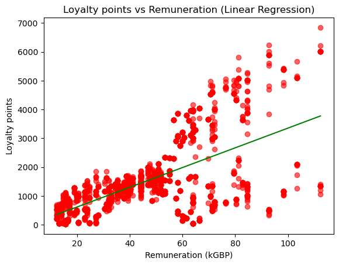

```python
# Plot graph with regression line.
import numpy as np
import matplotlib.pyplot as plt

plt.figure()
plt.scatter(reviews[X_col], reviews[y_col], alpha=0.6, color = 'red')

x_line = np.linspace(reviews[X_col].min(), reviews[X_col].max(), 200)
y_line = intercept + beta_pay * x_line
plt.plot(x_line, y_line, color = 'green')

plt.xlabel('Remuneration (kGBP)')
plt.ylabel('Loyalty points')
plt.title('Loyalty points vs Remuneration (Linear Regression)')
plt.show()
```

```python
# Define independent variable.
X_col = 'age'

# Define dependent variable.
y_col = 'loyalty_points'

# Create model and print summary of metrics.
import statsmodels.formula.api as smf
model_age = smf.ols(f'{y_col} ~ {X_col}', data=reviews).fit()
print("R-squared:", round(model_age.rsquared, 4))
print("Adj. R-squared:", round(model_age.rsquared_adj, 4))

# Extract the estimated parameters.
intercept = model_age.params['Intercept']
beta_age  = model_age.params[X_col]
```

```
R-squared: 0.0018
Adj. R-squared: 0.0013
```

```python
# Extract the standard errors.
se_intercept = model_age.bse['Intercept']
se_age       = model_age.bse[X_col]

# Extract the predicted values.
y_hat_age = model_age.predict(reviews)

# Set the X coefficient and the constant to generate the regression table.
import pandas as pd
reg_table_age = pd.DataFrame({
    'term': ['Intercept', 'Age'],
    'coefficient': [intercept, beta_age],
    'std_error': [se_intercept, se_age],
    'p_value': [model_age.pvalues['Intercept'], model_age.pvalues[X_col]]
}).round(5)

# View the output.
reg_table_age
```

|  | term | coefficient | std_error | p_value |
| --- | --- | --- | --- | --- |
| 0 | Intercept | 1736.51774 | 88.24873 | 0.00000 |
| 1 | Age | -4.01281 | 2.11318 | 0.05772 |

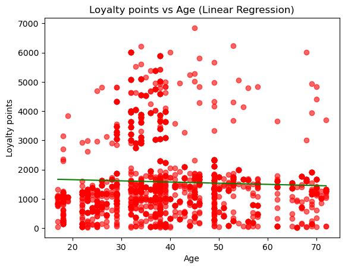

```python
# Plot graph with regression line.
import numpy as np
import matplotlib.pyplot as plt

plt.figure()
plt.scatter(reviews[X_col], reviews[y_col], alpha=0.6, color= 'red')

x_line = np.linspace(reviews[X_col].min(), reviews[X_col].max(), 200)
y_line = intercept + beta_age * x_line
plt.plot(x_line, y_line, color = 'green')

plt.xlabel('Age')
plt.ylabel('Loyalty points')
plt.title('Loyalty points vs Age (Linear Regression)')
plt.show()
```

# Age - Loyalty

Observations

Line is near-flat or slightly negative; very low R².

Dense clusters by cohort but no strong linear pattern.

Interpretation

Age alone isn’t a good predictor in a straight line.

Suggestions

Don’t target on age alone; tailor to cohort instead.

Notes/limits

Possible cohort late-20s/30s peak

# Remuneration - Loyalty

Observations

Strong positive relationship; higher pay aligns with more points.

Spread widens at higher remuneration.

Suggestions

Create premium tiers/VIP offers, finance/credit-backed bundles.

# Spending score - Loyalty

Observations

Clear upward trend; points increase as spending score rises.

Variance grows at high scores.

Visible clusters around mid-50s and 80–90.

Suggestions

Incentivise moves from 40–60 to 70+ (tiered perks, bundles, threshold bonuses).

Use spend thresholds in campaigns and retarget mid-spenders.

Monitor diminishing returns & fairness.

# Summary

What to explore further: refine the regression by including spending score and remuneration together (multiple linear regression), check coefficient stability, examine residuals (normality and constant variance), and test simple transformations (e.g., log of loyalty points or remuneration) if assumptions look strained.

Suggested actions: prioritize spend-uplift tactics (e.g., clear point thresholds and bundles) and trial value-aligned offers for higher-remuneration customers. Use age mainly for messaging/creative rather than targeting. Continue to document assumptions, note any warnings, and version the cleaned dataset for reuse.

### Assignment Activity 2.ipynb

## *last modified: 2025-10-03 05:16:14*

```python
# 1. Load and prepare the data
# Import all the necessary packages
import numpy as np
import pandas as pd
from sklearn.tree import DecisionTreeRegressor, plot_tree
from sklearn.metrics import mean_absolute_error, mean_squared_error, r2_score  # (regression metrics)
from sklearn.model_selection import train_test_split
import statsmodels.api as sm  # (not used here, but fine to keep)
import warnings
import matplotlib.pyplot as plt

warnings.filterwarnings("ignore")
plt.rcParams['figure.figsize'] = [15, 10]
RANDOM_STATE = 42
```

```python
# Create your new DataFrame.
df2 = pd.read_csv('turtle_reviews_clean.csv')
df2.head()
```

|  | age | remuneration_kgbp | spending_score | loyalty_points |
| --- | --- | --- | --- | --- |
| 0 | 18.0 | 12.30 | 39 | 210.0 |
| 1 | 23.0 | 12.30 | 81 | 524.0 |
| 2 | 22.0 | 13.12 | 6 | 40.0 |
| 3 | 25.0 | 13.12 | 77 | 562.0 |
| 4 | 33.0 | 13.94 | 40 | 366.0 |

```python
# Specify Y.
y = df2['loyalty_points'].copy()

# Specify X.
feature_cols = ['age', 'remuneration_kgbp', 'spending_score']
X = df2[feature_cols].copy()
```

```python
# Review X and Y.
print("X shape:", X.shape)
print("y shape:", y.shape)
X.head(), y.head()
```

```
X shape: (2000, 3)
y shape: (2000,)
```

```
(    age  remuneration_kgbp  spending_score
 0  18.0              12.30              39
 1  23.0              12.30              81
 2  22.0              13.12               6
 3  25.0              13.12              77
 4  33.0              13.94              40,
 0    210.0
 1    524.0
 2     40.0
 3    562.0
 4    366.0
 Name: loyalty_points, dtype: float64)
```

```python
# Split the data into test and train data.
X_train, X_test, y_train, y_test = train_test_split(
    X, y, test_size=0.30, random_state=RANDOM_STATE
)
X_train.shape, X_test.shape
```

```
((1400, 3), (600, 3))
```

```python
# Create your decision tree regressor. (Baseline, unpruned)
regressor_base = DecisionTreeRegressor(random_state=RANDOM_STATE)
regressor_base.fit(X_train, y_train)

# Evaluate the model.
def print_metrics(y_tr, y_tr_pred, y_te, y_te_pred, label="Model"):
    mse_tr = mean_squared_error(y_tr, y_tr_pred)
    mse_te = mean_squared_error(y_te, y_te_pred)
    rmse_tr = np.sqrt(mse_tr)
    rmse_te = np.sqrt(mse_te)
    mae_tr  = mean_absolute_error(y_tr, y_tr_pred)
    mae_te  = mean_absolute_error(y_te, y_te_pred)
    r2_tr   = r2_score(y_tr, y_tr_pred)
    r2_te   = r2_score(y_te, y_te_pred)
    print(f"{label} — TRAIN  RMSE: {rmse_tr:.1f} | MAE: {mae_tr:.1f} | R²: {r2_tr:.3f}")
    print(f"{label} — TEST   RMSE: {rmse_te:.1f}  | MAE: {mae_te:.1f}  | R²: {r2_te:.3f}")

y_pred_train_base = regressor_base.predict(X_train)
y_pred_test_base  = regressor_base.predict(X_test)
print_metrics(y_train, y_pred_train_base, y_test, y_pred_test_base, label="Baseline tree")
```

```
Baseline tree — TRAIN  RMSE: 0.0 | MAE: 0.0 | R²: 1.000
Baseline tree — TEST   RMSE: 81.3  | MAE: 27.0  | R²: 0.996
```

```python
# Prune the model.
candidates = []
for max_depth in [3, 4, 5, 6]:
    for min_leaf in [1, 5, 10]:
        m = DecisionTreeRegressor(
            random_state=RANDOM_STATE,
            max_depth=max_depth,
            min_samples_leaf=min_leaf
        )
        m.fit(X_train, y_train)
        r2_te = r2_score(y_test, m.predict(X_test))
        candidates.append((max_depth, min_leaf, r2_te, m))

# Pick the best by test R²
best_max_depth, best_min_leaf, best_r2_test, best_model = max(candidates, key=lambda t: t[2])
print(f"Best params → max_depth={best_max_depth}, min_samples_leaf={best_min_leaf}, test R²={best_r2_test:.3f}")
```

```
Best params → max_depth=6, min_samples_leaf=10, test R²=0.974
```

```python
# Fit and plot final model.
regressor_pruned = DecisionTreeRegressor(
    random_state=RANDOM_STATE,
    max_depth=best_max_depth,
    min_samples_leaf=best_min_leaf
)
regressor_pruned.fit(X_train, y_train)

# Evaluate pruned model
y_pred_train_pruned = regressor_pruned.predict(X_train)
y_pred_test_pruned  = regressor_pruned.predict(X_test)
print_metrics(y_train, y_pred_train_pruned, y_test, y_pred_test_pruned, label="Pruned tree")

# Feature importance (which inputs mattered most)
importances = pd.Series(regressor_pruned.feature_importances_, index=feature_cols).sort_values(ascending=False)
print("\nFeature importances:\n", importances)
```

```
Pruned tree — TRAIN  RMSE: 181.7 | MAE: 127.7 | R²: 0.980
Pruned tree — TEST   RMSE: 202.5  | MAE: 137.6  | R²: 0.974

Feature importances:
 remuneration_kgbp    0.506566
spending_score       0.483281
age                  0.010153
dtype: float64
```

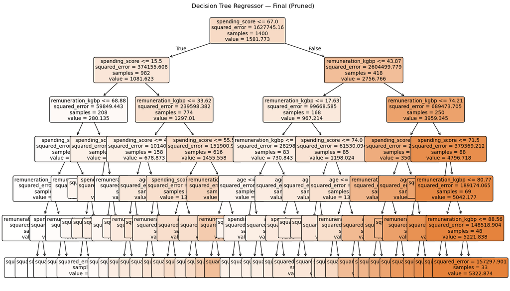

```python
plt.figure(figsize=(16, 10))
plot_tree(
    regressor_pruned,
    feature_names=feature_cols,
    filled=True,
    rounded=True,
    fontsize=10
)
plt.title("Decision Tree Regressor — Final (Pruned)")
plt.show()
```

# Insights and observations

Usefulness

The pruned tree generalises well: R²(test)=0.974 vs R²(train)=0.980. The baseline tree hit R²(train)=1.00 (classic overfit) even though test R² was very high; pruning trades a little fit for a simpler, more stable model.

Interpretability is high: the model surfaces a small set of clear thresholds that a non-technical audience can act on.

What the tree says (read top→down)

Low spend (≤ 15.5): very low loyalty; even higher remuneration rarely compensates - low ROI segment.

High spend (> 67): remuneration thresholds at 43.9k, 74.2k, 80.8k, 88.6k separate high - very high loyalty bands; a minor spending nudge around 71.5 further boosts value.

How to use this for the business

Tiered offers by spending:

≤15.5: light, low-cost nurture only.

15.5–67: threshold bonuses (e.g., extra points at 55 and 67) to push into the high tier.

67: protect value with VIP perks; add a micro-nudge around 71.5.

Remuneration bands: add premium/VIP benefits above 74k and 88.6k; below 44k, use value bundles rather than premium credit perks.

Age: do not target on age; use only for messaging tone/channels.

Caveats: validate thresholds with A/B tests, monitor fairness, and re-check stability with K-fold CV.

# Summary

What to do with this: • For low spenders (around fifteen or below), keep costs low and use light-touch nurture. • For mid spenders (roughly fifteen to sixty-seven), push them over key thresholds with bonus points, bundles, and clear “spend more, earn more” offers. • For high spenders, protect and grow value with VIP benefits and premium offers. • For higher-income customers, offer premium tiers and early access; for lower-income customers, focus on value packs rather than credit or luxury perks.

These rules are simple to explain to the business and can be A/B tested quickly.

### Assignment Activity 3.ipynb

## *last modified: 2025-10-03 05:17:44*

```python
## 1. Load and explore the data
# Import necessary libraries.
import numpy as np
import pandas as pd
import matplotlib.pyplot as plt
import matplotlib.cm as cm
import seaborn as sns

from sklearn.preprocessing import StandardScaler
from sklearn.cluster import KMeans
from sklearn.metrics import silhouette_score
from scipy.spatial.distance import cdist

import warnings
warnings.filterwarnings('ignore')
plt.rcParams['figure.figsize'] = [15, 10]
RANDOM_STATE = 42
```

```python
# Load the CSV file(s) as df2.
df2 = pd.read_csv("turtle_reviews_clean.csv")

# Handle column naming differences (renumeration vs remuneration_kgbp)
rename_map = {}
if 'renumeration' in df2.columns:
    rename_map['renumeration'] = 'remuneration_kgbp'
if 'remuneration_(k£)' in df2.columns:
    rename_map['remuneration_(k£)'] = 'remuneration_kgbp'
if rename_map:
    df2 = df2.rename(columns=rename_map)

df2.head()
```

|  | age | remuneration_kgbp | spending_score | loyalty_points |
| --- | --- | --- | --- | --- |
| 0 | 18.0 | 12.30 | 39 | 210.0 |
| 1 | 23.0 | 12.30 | 81 | 524.0 |
| 2 | 22.0 | 13.12 | 6 | 40.0 |
| 3 | 25.0 | 13.12 | 77 | 562.0 |
| 4 | 33.0 | 13.94 | 40 | 366.0 |

```python
# View DataFrame.
df2.info()

# Drop unnecessary columns.
for col in ['language','platform']:
    if col in df2.columns:
        df2 = df2.drop(columns=col)

# Create df3 with only remuneration & spending_score.
df3 = df2[['remuneration_kgbp','spending_score']].copy()
```

```
<class 'pandas.core.frame.DataFrame'>
RangeIndex: 2000 entries, 0 to 1999
Data columns (total 4 columns):
 #   Column             Non-Null Count  Dtype
---  ------             --------------  -----
 0   age                2000 non-null   float64
 1   remuneration_kgbp  2000 non-null   float64
 2   spending_score     2000 non-null   int64
 3   loyalty_points     2000 non-null   float64
dtypes: float64(3), int64(1)
memory usage: 62.6 KB
```

```python
# View DataFrame.
df3.head()

# Explore the data.
print(df3.describe())
```

```
       remuneration_kgbp  spending_score
count        2000.000000     2000.000000
mean           47.989762       50.009000
std            22.891614       26.052203
min            12.300000        3.000000
25%            30.340000       32.000000
50%            47.150000       50.000000
75%            63.960000       73.000000
max           103.410200       98.000000
```

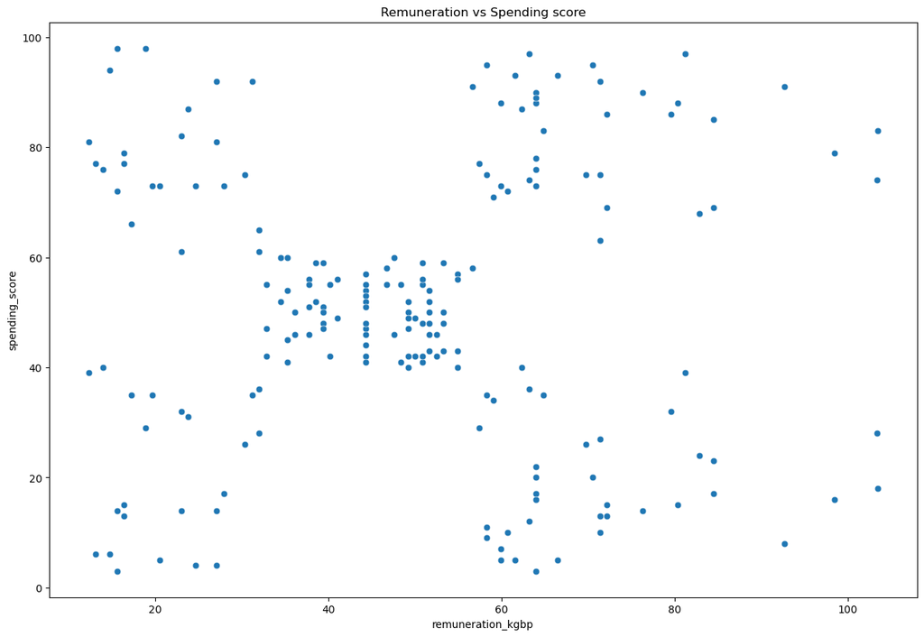

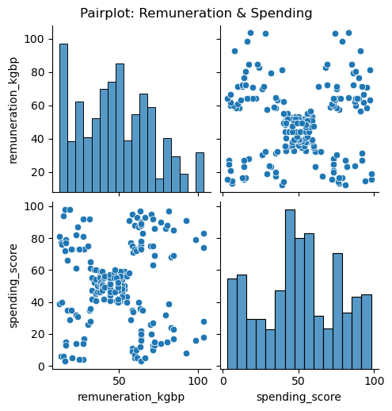

```python
## 2. Plot
# Create a scatterplot with Seaborn.
sns.scatterplot(data=df3, x='remuneration_kgbp', y='spending_score', s=40, alpha=0.7)
plt.title('Remuneration vs Spending score')
plt.show()

# Create a pairplot with Seaborn.
sns.pairplot(df3)
plt.suptitle('Pairplot: Remuneration & Spending', y=1.02)
plt.show()
```

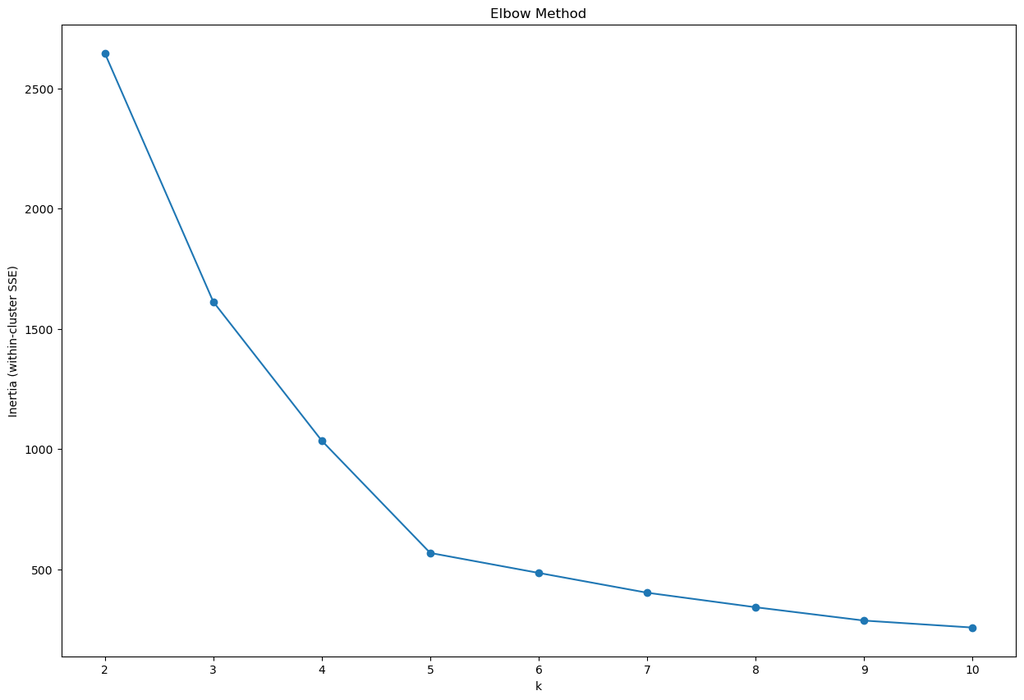

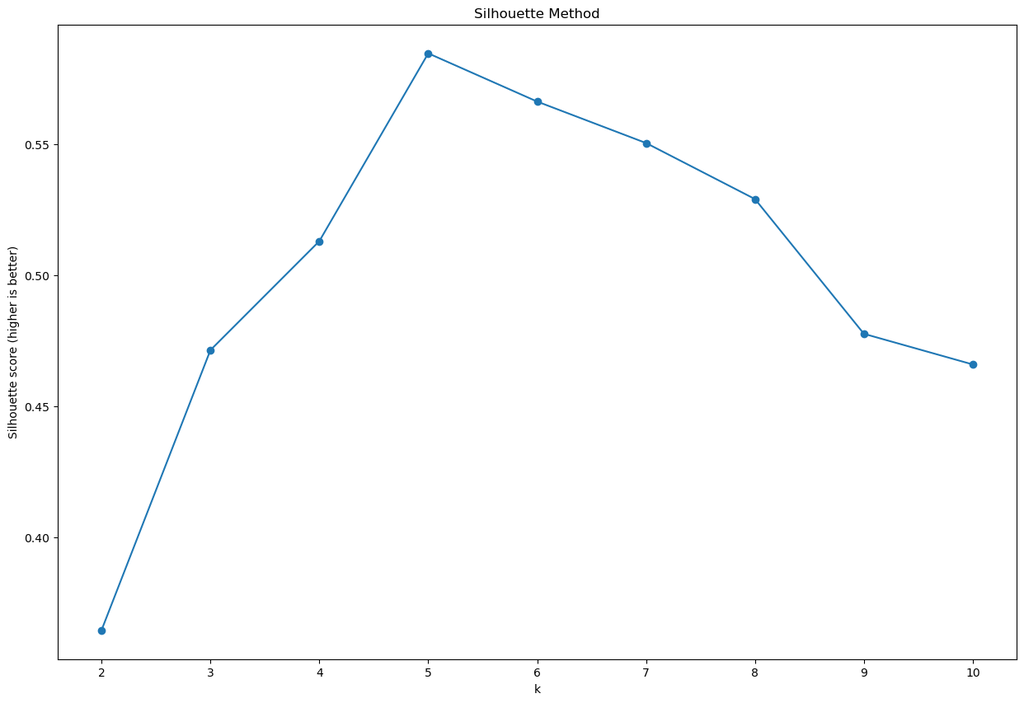

```
    k  silhouette      inertia
0   2    0.364622  2646.170131
1   3    0.471513  1612.378868
2   4    0.513106  1034.811144
3   5    0.584765   567.930243
4   6    0.566365   484.857319
5   7    0.550539   402.521257
6   8    0.529157   342.112138
7   9    0.477739   286.708016
8  10    0.466045   257.708019
```

```python
## 3. Elbow and silhouette methods
# Standardise features for k-means.
scaler = StandardScaler()
X = df3[['remuneration_kgbp','spending_score']].values
X_scaled = scaler.fit_transform(X)

# Determine the number of clusters: Elbow method.
ks = list(range(2, 11))
inertias = []
for k in ks:
    km = KMeans(n_clusters=k, random_state=RANDOM_STATE, n_init=10)
    km.fit(X_scaled)
    inertias.append(km.inertia_)

plt.plot(ks, inertias, marker='o')
plt.xticks(ks)
plt.xlabel('k')
plt.ylabel('Inertia (within-cluster SSE)')
plt.title('Elbow Method')
plt.show()

# Determine the number of clusters: Silhouette method.
sil_scores = []
for k in ks:
    km = KMeans(n_clusters=k, random_state=RANDOM_STATE, n_init=10)
    labels = km.fit_predict(X_scaled)
    sil = silhouette_score(X_scaled, labels)
    sil_scores.append(sil)

plt.plot(ks, sil_scores, marker='o')
plt.xticks(ks)
plt.xlabel('k')
plt.ylabel('Silhouette score (higher is better)')
plt.title('Silhouette Method')
plt.show()

print(pd.DataFrame({'k': ks, 'silhouette': sil_scores, 'inertia': inertias}))
```

```
Cluster sizes for k=5:
cluster_k5
0    356
1    271
2    330
3    269
4    774
Name: count, dtype: int64
```

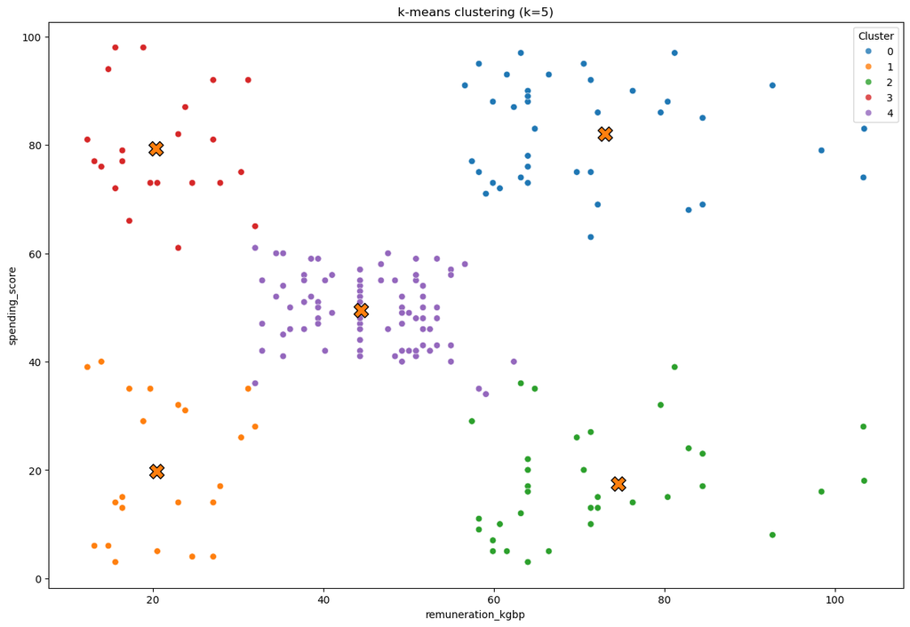

```python
## 4. Evaluate k-means model at different values of *k*
def plot_kmeans(k):
    km = KMeans(n_clusters=k, random_state=RANDOM_STATE, n_init=10)
    labels = km.fit_predict(X_scaled)
    centers_scaled = km.cluster_centers_
    centers = scaler.inverse_transform(centers_scaled)

    # Attach labels for inspection
    out = df3.copy()
    out[f'cluster_k{k}'] = labels
    print(f"\nCluster sizes for k={k}:")
    print(out[f'cluster_k{k}'].value_counts().sort_index())

    # Plot
    palette = sns.color_palette(n_colors=k)
    sns.scatterplot(
        x=out['remuneration_kgbp'], y=out['spending_score'],
        hue=out[f'cluster_k{k}'], palette=palette, s=40, alpha=0.8, legend='full'
    )
    plt.scatter(centers[:,0], centers[:,1], marker='X', s=200, edgecolor='black')
    plt.title(f'k-means clustering (k={k})')
    plt.legend(title='Cluster')
    plt.show()

for k in [5]:
    plot_kmeans(k)
```

```
Cluster sizes for k=3:
cluster_k3
0     356
1    1293
2     351
Name: count, dtype: int64
```

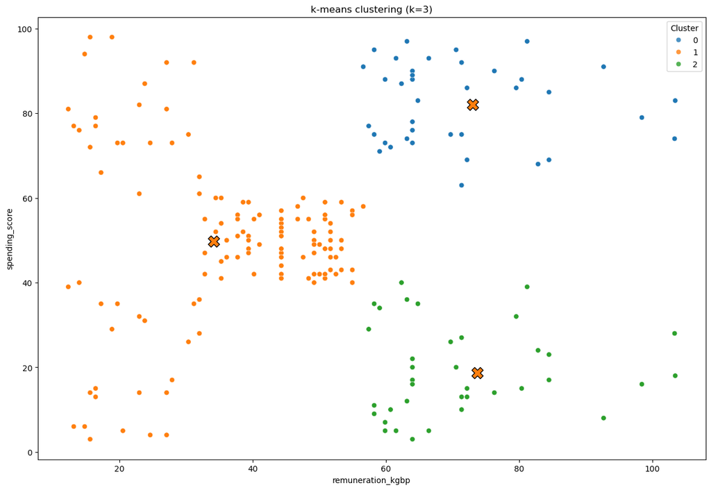

```python
## 4. Evaluate k-means model at different values of *k*
def plot_kmeans(k):
    km = KMeans(n_clusters=k, random_state=RANDOM_STATE, n_init=10)
    labels = km.fit_predict(X_scaled)
    centers_scaled = km.cluster_centers_
    centers = scaler.inverse_transform(centers_scaled)

    # Attach labels for inspection
    out = df3.copy()
    out[f'cluster_k{k}'] = labels
    print(f"\nCluster sizes for k={k}:")
    print(out[f'cluster_k{k}'].value_counts().sort_index())

    # Plot
    palette = sns.color_palette(n_colors=k)
    sns.scatterplot(
        x=out['remuneration_kgbp'], y=out['spending_score'],
        hue=out[f'cluster_k{k}'], palette=palette, s=40, alpha=0.8, legend='full'
    )
    plt.scatter(centers[:,0], centers[:,1], marker='X', s=200, edgecolor='black')
    plt.title(f'k-means clustering (k={k})')
    plt.legend(title='Cluster')
    plt.show()

for k in [3]:
    plot_kmeans(k)
```

```python
## 5. Fit final model and justify your choice
# Force k = 5 because the silhouette method peaked at 5.
from sklearn.cluster import KMeans
from sklearn.metrics import silhouette_score

kfinal = 5
kmeans_final = KMeans(n_clusters=kfinal, random_state=RANDOM_STATE, n_init=10)

# Fit on the scaled features and get labels
final_labels = kmeans_final.fit_predict(X_scaled)

# Attach labels to the working DataFrame
df3 = df3.copy()
df3['cluster'] = final_labels

# Check the number of observations per predicted class.
cluster_sizes = df3['cluster'].value_counts().sort_index()
print("Final cluster sizes:\n", cluster_sizes)

# Confirm silhouette for k=5 (higher is better)
sil_k5 = silhouette_score(X_scaled, final_labels)
print(f"Silhouette score (k=5): {sil_k5:.3f}")
```

```
Final cluster sizes:
 cluster
0    356
1    271
2    330
3    269
4    774
Name: count, dtype: int64
Silhouette score (k=5): 0.585
```

```python
## 6. Plot and interpret the clusters
# Compute cluster centers back in original units for readability
centers_scaled = kmeans_final.cluster_centers_
centers = scaler.inverse_transform(centers_scaled)

# Build a small centroids table with sizes and shares
import pandas as pd
centroids = pd.DataFrame(centers, columns=['remuneration_kgbp','spending_score'])
centroids['cluster'] = range(kfinal)
centroids = centroids.set_index('cluster').round(1)
centroids['size'] = cluster_sizes
centroids['share_%'] = (cluster_sizes / len(df3) * 100).round(1)
centroids
```

| cluster | remuneration_kgbp | spending_score | size | share_% |
| --- | --- | --- | --- | --- |
| 0 | 73.0 | 82.0 | 356 | 17.8 |
| 1 | 20.4 | 19.8 | 271 | 13.6 |
| 2 | 74.6 | 17.5 | 330 | 16.5 |
| 3 | 20.4 | 79.4 | 269 | 13.4 |
| 4 | 44.4 | 49.5 | 774 | 38.7 |

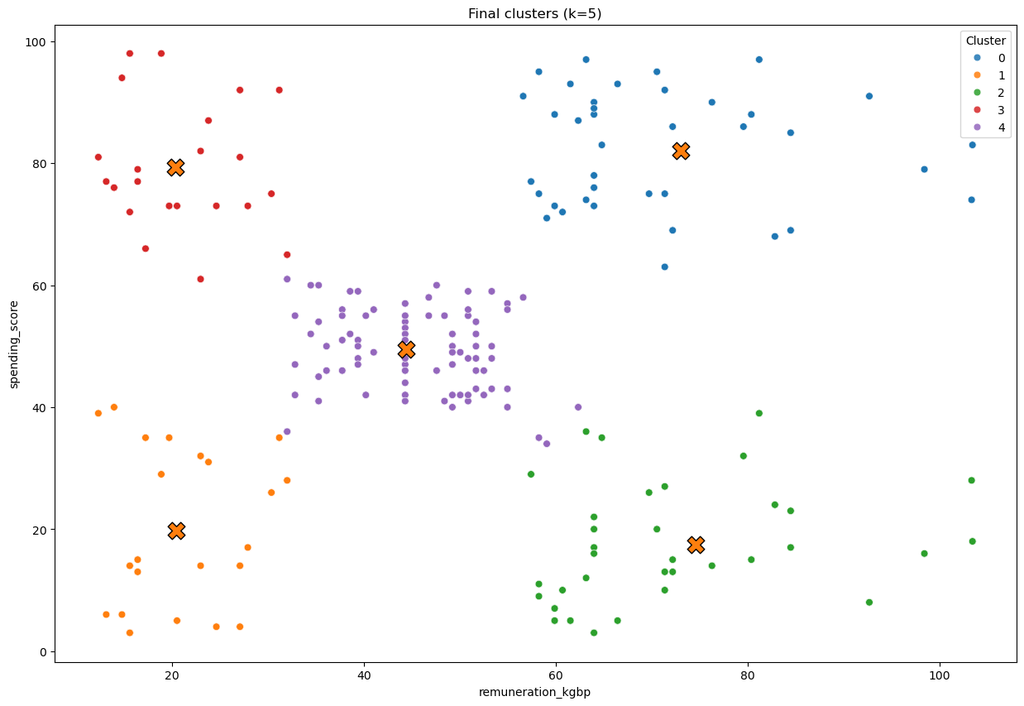

```python
# Visualising the clusters (k=5) with centers
import seaborn as sns
import matplotlib.pyplot as plt

palette = sns.color_palette(n_colors=kfinal)
sns.scatterplot(
    data=df3, x='remuneration_kgbp', y='spending_score',
    hue='cluster', palette=palette, s=40, alpha=0.85, legend='full'
)
plt.scatter(centers[:,0], centers[:,1], marker='X', s=220, edgecolor='black')
plt.title('Final clusters (k=5)')
plt.legend(title='Cluster')
plt.show()
```

# Insights and observations

Overview

Using k-means on remuneration_kgbp and spending_score, k = 5 (silhouette 0.585) produced five clear, business-meaningful segments.

a) Groups identified (plain-English descriptions)

C0 – High income, High spend (centroid ≈ £73k, 82): Premium customers with consistently high engagement.

C1 – Low income, Low spend (≈ £20k, 20): Low capacity and low activity; low immediate ROI.

C2 – High income, Low spend (≈ £74.6k, 17.5): Affluent but under-engaged; large headroom.

C3 – Low income, High spend (≈ £20.4k, 79.4): Deal-driven enthusiasts; value-sensitive, very active.

C4 – Mid income, Mid spend (Core) (≈ £44.4k, 49.5): Broad middle with clear uplift potential.

b) Relative sizes of the groups

C4 Core: 774 (38.7%) - largest lever

C0 High–High: 356 (17.8%)

C2 High–Low: 330 (16.5%)

C1 Low–Low: 271 (13.6%)

C3 Low–High: 269 (13.4%)

c) Specific actions / target priorities

C4 Core (mid–mid): Run tiered spend-threshold bonuses (e.g., 55 to 67), seasonal bundles, and cross-sells to lift into C0.

C0 High–High (vip): Protect & expand with VIP perks, early access, higher point multipliers on premium categories, concierge-style service.

C2 High–Low (affluent under-engaged): Activation campaigns (welcome/first-purchase boosters), personalised recommendations, premium category trials.

C3 Low–High (enthusiasts): Maintain high perceived value via non-cash perks, limited-time boosts; set margin guards and avoid credit-heavy offers.

C1 Low–Low (nurture): Low-cost nurture: value packs, app/email prompts, basic earn rates; cap rewards to keep CAC and reward cost low.

Notes: Use age only for messaging tone/channels, not targeting. Track lift in spending_score and loyalty_points by cluster to validate ROI.

# Summary

We grouped customers into five clear segments based on income and spending. Think of it as finding look-alike crowds so we can talk to each one the right way.

Core (about 4 in 10 customers): mid income, mid spend. This is our biggest lever. Give simple “spend a bit more, earn a lot more” offers and bundles to move them up.

VIPs (about 2 in 10): high income, high spend. Keep them loyal with early access, premium perks and occasional high-value bonuses.

Affluent but under-active (about 1½ in 10): high income, low spend. Wake them up with welcome/first-purchase boosts and recommendations for premium categories.

Value enthusiasts (about 1⅓ in 10): low income, high spend. They respond to strong value. Use time-limited boosters and non-cash perks, but watch margin.

Low activity (about 1⅓ in 10): low income, low spend. Keep costs low—simple nurture, value packs, app/email reminders.

What to do next: tag these segments in the CRM, run small A/B tests per group (e.g., threshold bonuses for Core, VIP perks for VIPs), and track two numbers for each segment—spending score and loyalty points—to confirm what’s working and where to push harder.

### Assignment Activity 4.ipynb

## *last modified: 2025-09-15 16:04:07*

```python
# Import all the necessary packages.
import pandas as pd
import numpy as np
import nltk
import os
import matplotlib.pyplot as plt

# nltk.download ('punkt').
# nltk.download ('stopwords').

from wordcloud import WordCloud
from nltk.tokenize import word_tokenize
from nltk.probability import FreqDist
from nltk.corpus import stopwords
from textblob import TextBlob
from scipy.stats import norm

# Import Counter.
from collections import Counter

import warnings
warnings.filterwarnings('ignore')
```

```python
# Load the data set as df3.
df3 = pd.read_csv("turtle_reviews.csv")

# View DataFrame.
df3.head()
```

|  | gender | age | remuneration (k£) | spending_score (1-100) | loyalty_points | education | language | platform | product | review | summary |
| --- | --- | --- | --- | --- | --- | --- | --- | --- | --- | --- | --- |
| 0 | Male | 18 | 12.30 | 39 | 210 | graduate | EN | Web | 453 | When it comes to a DM's screen, the space on t... | The fact that 50% of this space is wasted on a... |
| 1 | Male | 23 | 12.30 | 81 | 524 | graduate | EN | Web | 466 | An Open Letter to GaleForce9*:\n\nYour unpaint... | Another worthless Dungeon Master's screen from... |
| 2 | Female | 22 | 13.12 | 6 | 40 | graduate | EN | Web | 254 | Nice art, nice printing. Why two panels are f... | pretty, but also pretty useless |
| 3 | Female | 25 | 13.12 | 77 | 562 | graduate | EN | Web | 263 | Amazing buy! Bought it as a gift for our new d... | Five Stars |
| 4 | Female | 33 | 13.94 | 40 | 366 | graduate | EN | Web | 291 | As my review of GF9's previous screens these w... | Money trap |

```python
# Explore data set.
df3.info()
```

```
<class 'pandas.core.frame.DataFrame'>
RangeIndex: 2000 entries, 0 to 1999
Data columns (total 11 columns):
 #   Column                  Non-Null Count  Dtype
---  ------                  --------------  -----
 0   gender                  2000 non-null   object
 1   age                     2000 non-null   int64
 2   remuneration (k£)       2000 non-null   float64
 3   spending_score (1-100)  2000 non-null   int64
 4   loyalty_points          2000 non-null   int64
 5   education               2000 non-null   object
 6   language                2000 non-null   object
 7   platform                2000 non-null   object
 8   product                 2000 non-null   int64
 9   review                  2000 non-null   object
 10  summary                 2000 non-null   object
dtypes: float64(1), int64(4), object(6)
memory usage: 172.0+ KB
```

```python
# Keep necessary columns. Drop unnecessary columns.
df3 = df3[['review', 'summary']].copy()
```

```python
# Determine if there are any missing values.
df3.isna().sum()
```

```
review     0
summary    0
dtype: int64
```

```python
# Review: Change all to lower case and join with a space.
df3['review'] = df3['review'].astype(str).str.lower().str.split().str.join(' ')
```

```python
# Summary: Change all to lower case and join with a space.
df3['summary'] = df3['summary'].astype(str).str.lower().str.split().str.join(' ')
```

```python
# Replace all the punctuations in review column.
import re, string
df3['review'] = df3['review'].str.replace(f"[{re.escape(string.punctuation)}]", " ", regex=True).str.replace(r"\s+", " ", regex=True).str.strip()

# View output.
df3['review'].head()
```

```
0    when it comes to a dm s screen the space on th...
1    an open letter to galeforce9 your unpainted mi...
2    nice art nice printing why two panels are fill...
3    amazing buy bought it as a gift for our new dm...
4    as my review of gf9 s previous screens these w...
Name: review, dtype: object
```

```python
# Replace all the puncuations in summary column.
df3['summary'] = df3['summary'].str.replace(f"[{re.escape(string.punctuation)}]", " ", regex=True).str.replace(r"\s+", " ", regex=True).str.strip()

# View output.
df3['summary'].head()
```

```
0    the fact that 50 of this space is wasted on ar...
1    another worthless dungeon master s screen from...
2                       pretty but also pretty useless
3                                           five stars
4                                           money trap
Name: summary, dtype: object
```

```python
# Drop duplicates in both columns.
df3 = df3.drop_duplicates(subset=['review', 'summary'])

# View DataFrame.
df3.head()
```

|  | review | summary |
| --- | --- | --- |
| 0 | when it comes to a dm s screen the space on th... | the fact that 50 of this space is wasted on ar... |
| 1 | an open letter to galeforce9 your unpainted mi... | another worthless dungeon master s screen from... |
| 2 | nice art nice printing why two panels are fill... | pretty but also pretty useless |
| 3 | amazing buy bought it as a gift for our new dm... | five stars |
| 4 | as my review of gf9 s previous screens these w... | money trap |

```python
# Create new DataFrame (copy DataFrame).
df_wc = df3.copy()

# View DataFrame.
df_wc.head()
```

|  | review | summary |
| --- | --- | --- |
| 0 | when it comes to a dm s screen the space on th... | the fact that 50 of this space is wasted on ar... |
| 1 | an open letter to galeforce9 your unpainted mi... | another worthless dungeon master s screen from... |
| 2 | nice art nice printing why two panels are fill... | pretty but also pretty useless |
| 3 | amazing buy bought it as a gift for our new dm... | five stars |
| 4 | as my review of gf9 s previous screens these w... | money trap |

```python
# Apply tokenisation to both columns.
df_wc['review_tokens'] = df_wc['review'].apply(word_tokenize)
df_wc['summary_tokens'] = df_wc['summary'].apply(word_tokenize)

# View DataFrame.
df_wc[['review_tokens', 'summary_tokens']].head()
```

|  | review_tokens | summary_tokens |
| --- | --- | --- |
| 0 | [when, it, comes, to, a, dm, s, screen, the, s... | [the, fact, that, 50, of, this, space, is, was... |
| 1 | [an, open, letter, to, galeforce9, your, unpai... | [another, worthless, dungeon, master, s, scree... |
| 2 | [nice, art, nice, printing, why, two, panels, ... | [pretty, but, also, pretty, useless] |
| 3 | [amazing, buy, bought, it, as, a, gift, for, o... | [five, stars] |
| 4 | [as, my, review, of, gf9, s, previous, screens... | [money, trap] |

```python
# Review: Create a word cloud.
review_text = " ".join(df_wc['review'].astype(str).tolist())
wc_review = WordCloud(width=800, height=400, background_color='white').generate(review_text)
```

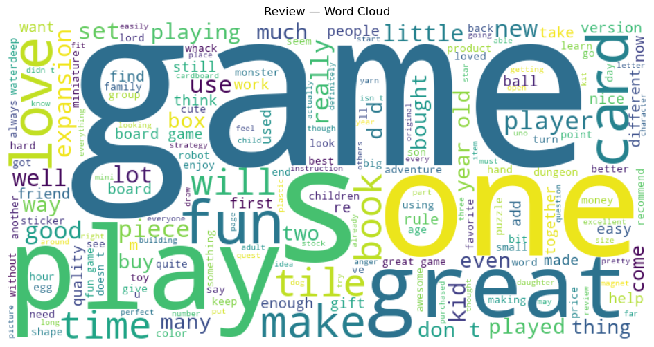

```python
# Review: Plot the WordCloud image.
plt.figure(figsize=(12, 6))
plt.imshow(wc_review, interpolation='bilinear')
plt.axis('off')
plt.title('Review — Word Cloud')
plt.show()
```

```python
# Summary: Create a word cloud.
summary_text = " ".join(df_wc['summary'].astype(str).tolist())
wc_summary = WordCloud(width=800, height=400, background_color='white').generate(summary_text)
```

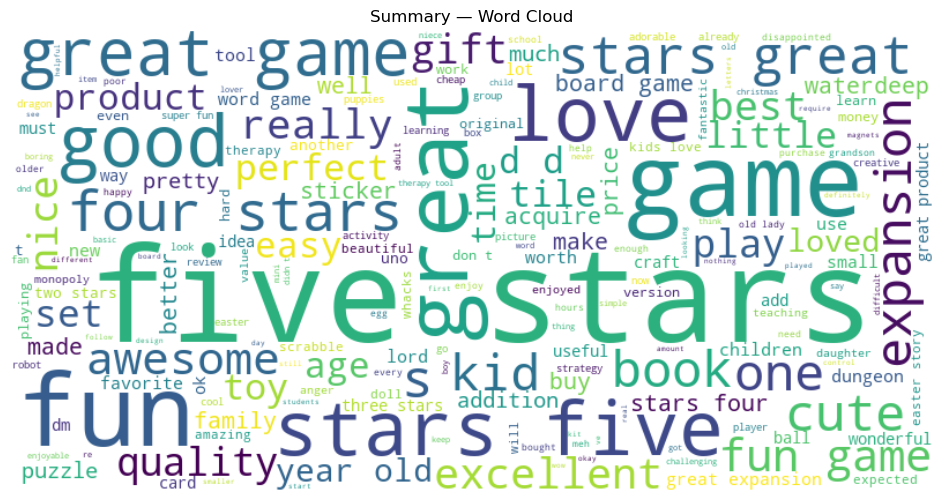

```python
# Summary: Plot the WordCloud image.
plt.figure(figsize=(12, 6))
plt.imshow(wc_summary, interpolation='bilinear')
plt.axis('off')
plt.title('Summary — Word Cloud')
plt.show()
```

```python
# Determine the frequency distribution.
review_words_raw = [w.lower() for tokens in df_wc['review_tokens'] for w in tokens]
summary_words_raw = [w.lower() for tokens in df_wc['summary_tokens'] for w in tokens]

fdist_review = FreqDist(review_words_raw)
fdist_summary = FreqDist(summary_words_raw)
```

```python
# Delete all the alpanum.
df_wc['review_tokens_alpha'] = df_wc['review_tokens'].apply(lambda toks: [w for w in toks if w.isalpha()])
df_wc['summary_tokens_alpha'] = df_wc['summary_tokens'].apply(lambda toks: [w for w in toks if w.isalpha()])

# Remove all the stopwords
stop_words = set(stopwords.words('english'))

df_wc['review_tokens_clean'] = df_wc['review_tokens_alpha'].apply(lambda toks: [w.lower() for w in toks if w.lower() not in stop_words])
df_wc['summary_tokens_clean'] = df_wc['summary_tokens_alpha'].apply(lambda toks: [w.lower() for w in toks if w.lower() not in stop_words])
```

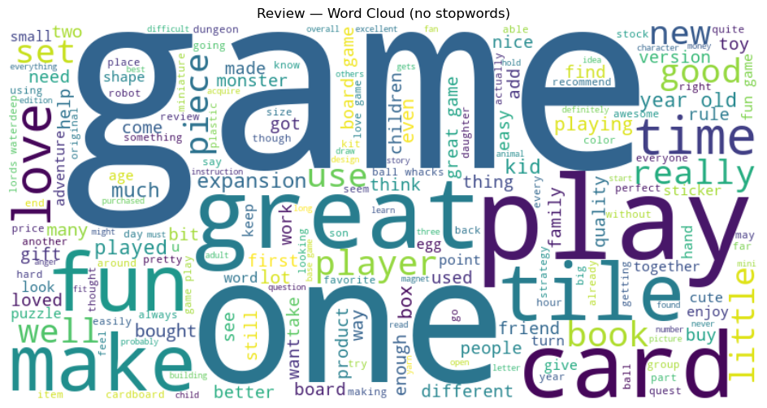

```python
# Create a wordcloud without stop words.
review_text_nostop = " ".join(" ".join(tokens) for tokens in df_wc['review_tokens_clean'])
wc_review_clean = WordCloud(width=800, height=400, background_color='white').generate(review_text_nostop)

# Plot the wordcloud image.
plt.figure(figsize=(12, 6))
plt.imshow(wc_review_clean, interpolation='bilinear')
plt.axis('off')
plt.title('Review — Word Cloud (no stopwords)')
plt.show()
```

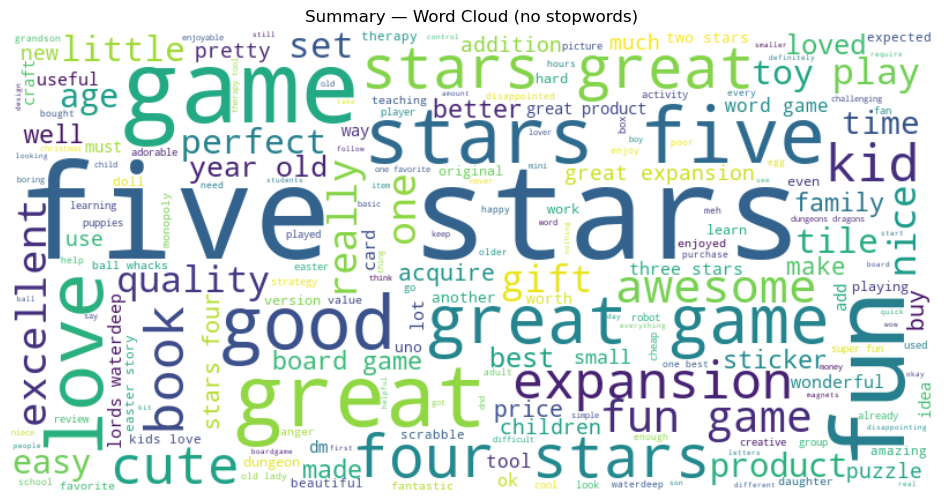

```python
# Create a wordcloud without stop words.
summary_text_nostop = " ".join(" ".join(tokens) for tokens in df_wc['summary_tokens_clean'])
wc_summary_clean = WordCloud(width=800, height=400, background_color='white').generate(summary_text_nostop)

# Plot the wordcloud image.
plt.figure(figsize=(12, 6))
plt.imshow(wc_summary_clean, interpolation='bilinear')
plt.axis('off')
plt.title('Summary — Word Cloud (no stopwords)')
plt.show()
```

```python
# Determine the 15 most common words.
review_flat = [w for tokens in df_wc['review_tokens_clean'] for w in tokens]
summary_flat = [w for tokens in df_wc['summary_tokens_clean'] for w in tokens]

top15_review = pd.DataFrame(Counter(review_flat).most_common(15), columns=['word', 'count'])
top15_summary = pd.DataFrame(Counter(summary_flat).most_common(15), columns=['word', 'count'])

top15_review, top15_summary
```

```
(      word  count
 0     game   1699
 1    great    582
 2      fun    557
 3      one    540
 4     play    509
 5     like    421
 6     love    324
 7      get    320
 8   really    319
 9    cards    306
 10   tiles    300
 11    time    297
 12    good    291
 13   would    283
```

[output cut: 17 more lines]

```python
# Provided function.
def generate_polarity(comment):
    '''Extract polarity score (-1 to +1) for each comment'''
    return TextBlob(comment).sentiment[0]
```

```python
# Determine polarity of both columns.
df_wc['review_polarity'] = df_wc['review'].astype(str).apply(generate_polarity)
df_wc['summary_polarity'] = df_wc['summary'].astype(str).apply(generate_polarity)

# View output.a
df_wc[['review_polarity', 'summary_polarity']].describe()
```

|  | review_polarity | summary_polarity |
| --- | --- | --- |
| count | 1961.000000 | 1961.000000 |
| mean | 0.212417 | 0.224397 |
| std | 0.260243 | 0.338296 |
| min | -1.000000 | -1.000000 |
| 25% | 0.044481 | 0.000000 |
| 50% | 0.177077 | 0.100000 |
| 75% | 0.350000 | 0.475000 |
| max | 1.000000 | 1.000000 |

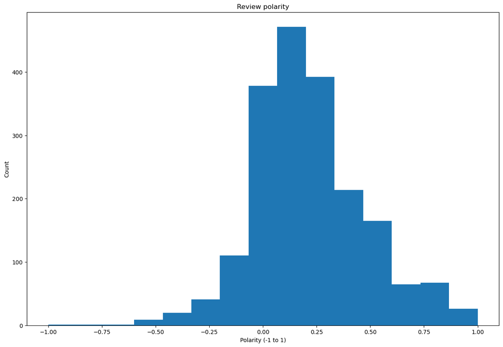

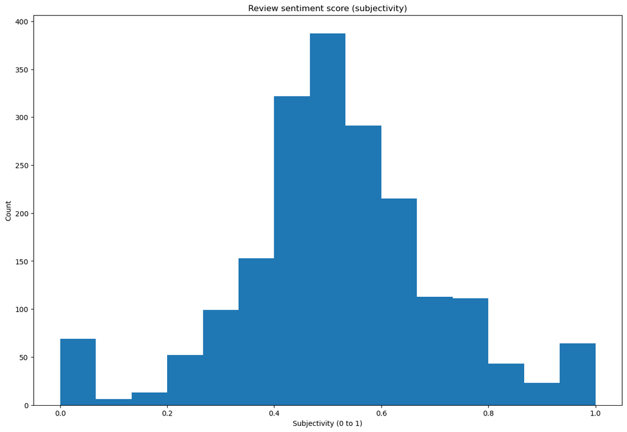

```python
# Review: Create a histogram plot with bins = 15.
# Histogram of polarity
df_wc['review_subjectivity'] = df_wc['review'].astype(str).apply(lambda c: TextBlob(c).sentiment.subjectivity)

plt.figure()
plt.hist(df_wc['review_polarity'].dropna(), bins=15)
plt.title('Review polarity')
plt.xlabel('Polarity (-1 to 1)')
plt.ylabel('Count')
plt.show()

# Histogram of sentiment score
plt.figure()
plt.hist(df_wc['review_subjectivity'].dropna(), bins=15)
plt.title('Review sentiment score (subjectivity)')
plt.xlabel('Subjectivity (0 to 1)')
plt.ylabel('Count')
plt.show()
```

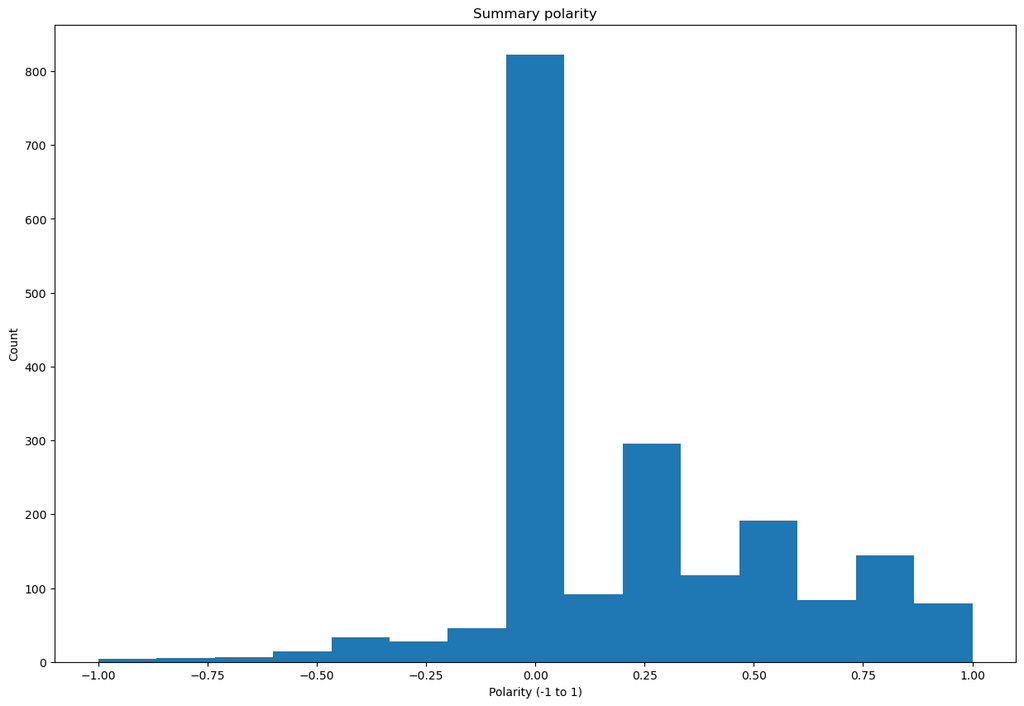

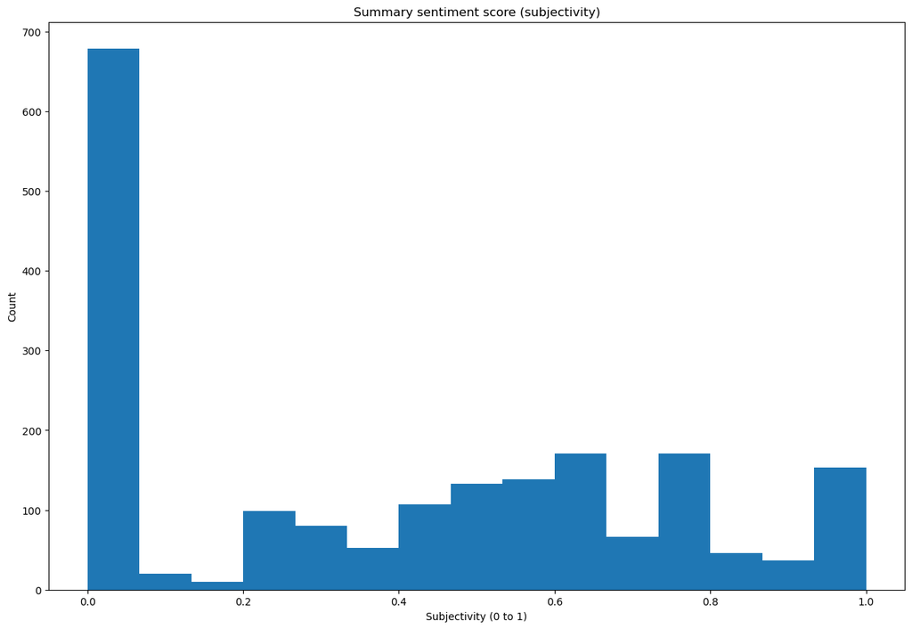

```python
# Summary: Create a histogram plot with bins = 15.
# Histogram of polarity
# (If not already created) compute subjectivity as the sentiment score
df_wc['summary_subjectivity'] = df_wc['summary'].astype(str).apply(lambda c: TextBlob(c).sentiment.subjectivity)

plt.figure()
plt.hist(df_wc['summary_polarity'].dropna(), bins=15)
plt.title('Summary polarity')
plt.xlabel('Polarity (-1 to 1)')
plt.ylabel('Count')
plt.show()

# Histogram of sentiment score
plt.figure()
plt.hist(df_wc['summary_subjectivity'].dropna(), bins=15)
plt.title('Summary sentiment score (subjectivity)')
plt.xlabel('Subjectivity (0 to 1)')
plt.ylabel('Count')
plt.show()
```

```python
# Top 20 positive reviews.
pos_reviews = df_wc[['review', 'review_polarity']].sort_values('review_polarity', ascending=False).head(20).reset_index(drop=True)

# View output.
pos_reviews
```

|  | review | review_polarity |
| --- | --- | --- |
| 0 | came in perfect condition | 1.0 |
| 1 | excellent activity for teaching self managemen... | 1.0 |
| 2 | excellent toy to simulate thought | 1.0 |
| 3 | it is the best thing to play with and also min... | 1.0 |
| 4 | awesome toy | 1.0 |
| 5 | awesome addition to my rpg gm system | 1.0 |
| 6 | perfect just what i ordered | 1.0 |
| 7 | it s awesome | 1.0 |
| 8 | awesome book | 1.0 |
| 9 | delightful product | 1.0 |
| 10 | wonderful product | 1.0 |
| 11 | awesome | 1.0 |
| 12 | awesome set | 1.0 |
| 13 | wonderful for my grandson to learn the resurre... | 1.0 |
| 14 | this was perfect to go with the 7 bean bags i ... | 1.0 |
| 15 | one of the best board games i played in along ... | 1.0 |
| 16 | perfect for tutoring my grandson in spelling | 1.0 |
| 17 | awesome gift | 1.0 |
| 18 | my daughter loves her stickers awesome seller ... | 1.0 |
| 19 | best set buy 2 if you have the means | 1.0 |

```python
# Top 20 positive summaries.
pos_summaries = df_wc[['summary', 'summary_polarity']].sort_values('summary_polarity', ascending=False).head(20).reset_index(drop=True)

# View output.
pos_summaries
```

|  | summary | summary_polarity |
| --- | --- | --- |
| 0 | excellent | 1.0 |
| 1 | best gm screen ever | 1.0 |
| 2 | wonderful | 1.0 |
| 3 | perfect | 1.0 |
| 4 | one of the best games ever | 1.0 |
| 5 | best easter teaching tool | 1.0 |
| 6 | excellent | 1.0 |
| 7 | the pigeon is the perfect addition to a school... | 1.0 |
| 8 | all f the mudpuppy toys are wonderful | 1.0 |
| 9 | awesome puzzle | 1.0 |
| 10 | not the best quality | 1.0 |
| 11 | awesome book | 1.0 |
| 12 | awesome expansion | 1.0 |
| 13 | adds a six player option and an excellent expa... | 1.0 |
| 14 | awesome sticker activity for the price | 1.0 |
| 15 | perfect for preschoolers | 1.0 |
| 16 | this a perfect must have set | 1.0 |
| 17 | master sets are best | 1.0 |
| 18 | awesome | 1.0 |
| 19 | just awesome | 1.0 |

```python
# Top 20 negative reviews.
neg_reviews = df_wc[['review', 'review_polarity']].sort_values('review_polarity', ascending=True).head(20).reset_index(drop=True)

# View output.
neg_reviews
```

|  | review | review_polarity |
| --- | --- | --- |
| 0 | booo unles you are patient know how to measure... | -1.000000 |
| 1 | incomplete kit very disappointing | -0.780000 |
| 2 | used with anger management group and they like... | -0.700000 |
| 3 | i m sorry i just find this product to be borin... | -0.583333 |
| 4 | one of my staff will be using this game soon s... | -0.550000 |
| 5 | i bought this as a christmas gift for my grand... | -0.500000 |
| 6 | difficult | -0.500000 |
| 7 | this was a gift for my daughter i found it dif... | -0.500000 |
| 8 | instructions are complicated to follow | -0.500000 |
| 9 | expensive for what you get | -0.500000 |
| 10 | i found the directions difficult | -0.500000 |
| 11 | i sent this product to my granddaughter the po... | -0.491667 |
| 12 | i purchased this on the recommendation of two ... | -0.440741 |
| 13 | very hard complicated to make these | -0.439583 |
| 14 | addicted to this game | -0.400000 |
| 15 | jun game | -0.400000 |
| 16 | kids i work with like this game | -0.400000 |
| 17 | scrabble in a card game | -0.400000 |
| 18 | this game although it appears to be like uno a... | -0.400000 |
| 19 | excelent expansion the game is nothing witout it | -0.400000 |

```python
# Top 20 negative summaries.
neg_summaries = df_wc[['summary', 'summary_polarity']].sort_values('summary_polarity', ascending=True).head(20).reset_index(drop=True)

# View output.
neg_summaries
```

|  | summary | summary_polarity |
| --- | --- | --- |
| 0 | boring | -1.000000 |
| 1 | the worst value i ve ever seen | -1.000000 |
| 2 | boring unless you are a craft person which i am | -1.000000 |
| 3 | before this i hated running any rpg campaign d... | -0.900000 |
| 4 | another worthless dungeon master s screen from... | -0.800000 |
| 5 | disappointed | -0.750000 |
| 6 | disappointed | -0.750000 |
| 7 | disappointed | -0.750000 |
| 8 | disappointed | -0.750000 |
| 9 | promotes anger instead of teaching calming met... | -0.700000 |
| 10 | bad quality all made of paper | -0.700000 |
| 11 | too bad this is not what i was expecting | -0.700000 |
| 12 | at age 31 i found these very difficult to make | -0.650000 |
| 13 | mad dragon | -0.625000 |
| 14 | small and boring | -0.625000 |
| 15 | disappointing | -0.600000 |
| 16 | disappointing | -0.600000 |
| 17 | disappointing | -0.600000 |
| 18 | disappointing | -0.600000 |
| 19 | then you will find this board game to be dumb ... | -0.591667 |

# Insights

Findings from word clouds (after cleaning and removing stopwords)

Reviews are full of product/use words: game, play, fun, tiles, cards, time, book, set, piece. This suggests people talk about how they use the products and what they liked in play.

So what? In listings and ads, lead with “fun / great / easy to play” language and show star ratings clearly. For families, highlight kids / family / expansion angles.

Frequency distribution (most common words)

Reviews: game, great, fun, play, like, love, cards, tiles, time, good, would, book.

Summaries: stars, five, game, great, fun, love, good, four, expansion, kids, cute. This split (usage terms in reviews vs. rating terms in summaries) supports using feature/benefit copy in long descriptions and ratings/badges in short spaces (thumbnails, cards).

Sentiment (polarity) — what tone do customers use?

Reviews (n≈1,961): mean +0.21, median +0.18, 25% ≈ +0.04, 75% ≈ +0.35; range −1.0 to +1.0.

Summaries (n≈1,961): mean +0.22, median +0.10, 25% ≈ 0.00, 75% ≈ +0.48; range −1.0 to +1.0.

Histograms show many neutral-to-positive comments and a long positive tail; a smaller set is clearly negative.

Subjectivity (how opinionated vs. factual)

Reviews cluster around 0.4–0.7 → moderately subjective (opinions + some facts).

Summaries show many near 0 (just “five stars”) plus a spread up to 1.0.

So what? Pull phrases from reviews for authentic quotes, and use star counts from summaries for quick-impact visuals.

Actionable recommendations

Merch & copy: Feature “fun,” “easy to play,” “great,” and family/kids benefits high up.

Badging: Put “Five-star” signals on product tiles and ads.

Upsell: Promote expansions to happy buyers; they appear often in summaries.

Support watchlist: A small negative segment exists; periodically sample those comments to catch themes (e.g., missing pieces, quality). Turn frequent issues into FAQs or fixes.

Notes & limits (for your report)

TextBlob gives a quick sentiment score but can miss sarcasm and domain slang.

Cleaning kept English words and removed punctuation; that can drop some emojis and brand terms.

Results describe this dataset (Turtle Games reviews); repeat monthly to spot shifts.

# Summary

Most customer comments are neutral to positive, with a strong tilt toward positive. Short “summary” lines often read like quick ratings (“five stars,” “great,” “fun”), while longer “reviews” talk about real use: game/play, tiles/cards, time with family/kids, and expansions. This tells us shoppers care about how easy and fun the product is to use, and they notice quality time and add-ons.

What to explore further: pull out a few common themes (e.g., “easy to learn,” “great for kids,”) to see which phrases drive better sales or fewer returns. Recheck the pattern each month to catch shifts (seasonality, new releases). Skim the small set of negative comments to spot fixable issues.

What to do now:

Lead product copy with “fun”, “easy to play,” and family/kids benefits.

Surface star ratings prominently on product tiles, ads, and search results.

Suggest expansions to happy buyers as a natural next step.

Create short replies for common concerns (e.g., missing pieces, quality), and turn repeated issues into quick FAQs.

Keep a light human review on headlines and sensitive claims.

Overall, the tone supports marketing that is simple, upbeat, family-friendly, and clear about value.